# Laboratorio54-Parte3-MD

Leislie R. Manjarrez O.

2023-03-17

Hecho con gusto por Leislie R. Manjarrez O.

Laboratorio 54- Dendrograma circular en R- Parte 3

La funcion circlize_dendrogram se puede utilizar para crear un dendrograma circular, tambien conocido como dendrograma polar o radial. Para ello es necesario pasar un objeto de la clase “dendrogram” a la funcion. Los argumentos labels_track_height y dend_track_height se usan para ajustar las etiquetas Tanto circlize como dendextend necesitan estar instalados para ejecutar la funcion

Instalamos la paqueteria correspondiente install.packages(“dendextend”) install.packages(“circlize”)

Llamamos a las librerias correspondientes

```r
library(dendextend)
library(circlize)
```

Creamos una matriz de distancias

```r
d <- dist(USArrests)
```

Generamos el cluster jerarquico

```r
hc <- as.dendrogram(hclust(d))
```

Dibujamos el dendrograma circular

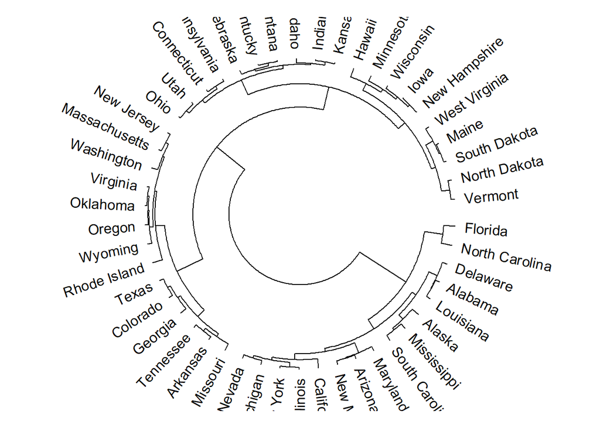

```r
circlize_dendrogram(hc,
                    labels_track_height = 0.1,
                    dend_track_height = 0.5)
```

El dendrograma que se crea por defecto muestra las ramas hacia el exterior, pero puedes cambiarlo con facing = “inside”

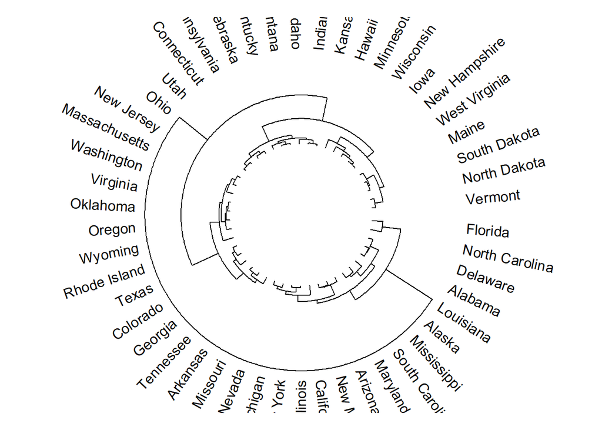

```r
circlize_dendrogram(hc,
                    labels_track_height = 0.1,
                    dend_track_height = 0.5,
                    facing = "inside")
```

Las etiquetas del dendrograma se pueden borrar si solo quieres mostrar las ramas estableciendo labels = FALSE. En este escenario es recomendable incrementar el argumento dend_track_height

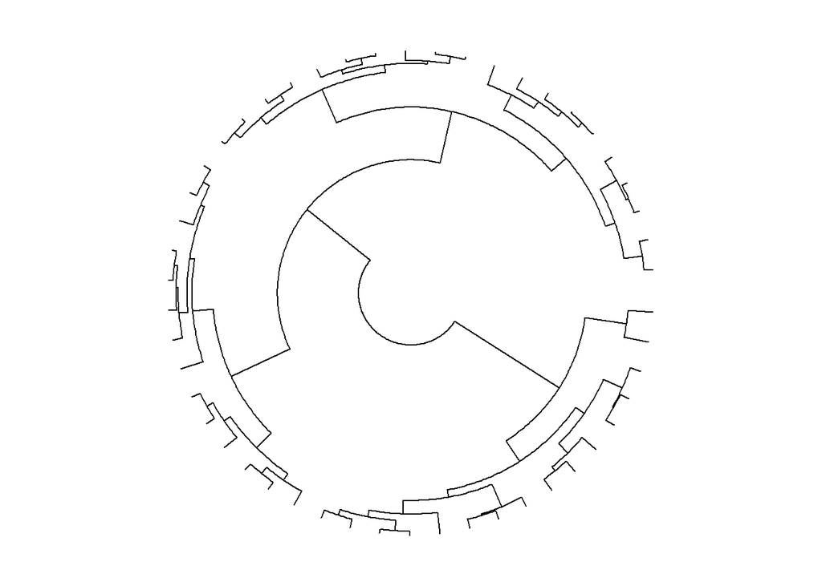

```r
circlize_dendrogram(hc,
                    dend_track_height = 0.8,
                    labels = FALSE)
```

Volvemos a colocar las etiquetas del dendrograma

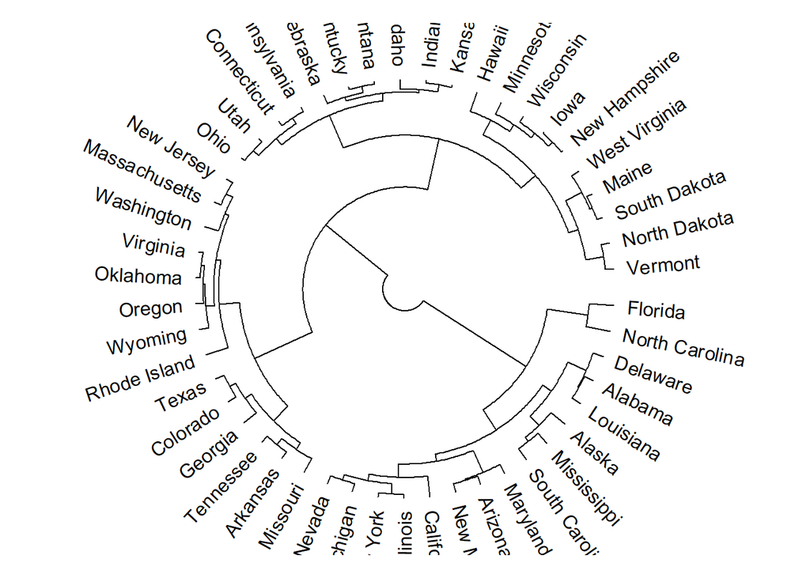

```r
circlize_dendrogram(hc,
                    dend_track_height = 0.8,
                    labels = TRUE)
```

Para colorear las ramas usamos la funcion color_branches, basandonos en el numero de grupos (k) o en una altura (h). La funcion contiene un argumento llamado col que permite personalizar los colores

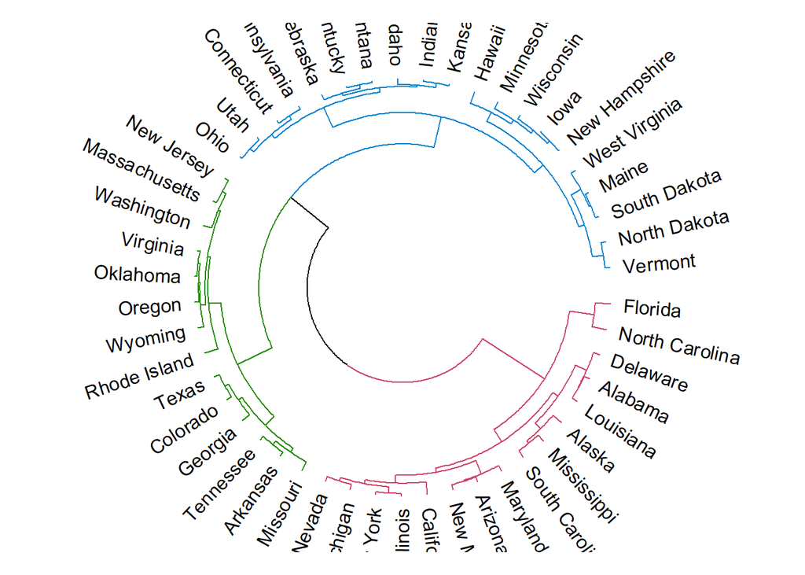

```r
hc <- hc %>%
  color_branches(k = 3)

circlize_dendrogram(hc,
                    labels_track_height = 0.1,
                    dend_track_height = 0.5)
```

Las etiquetas se pueden personalizar de la misma manera que las ramas. Usamos para ello la funcion color_labels y especifica el numero de grupos o la altura.

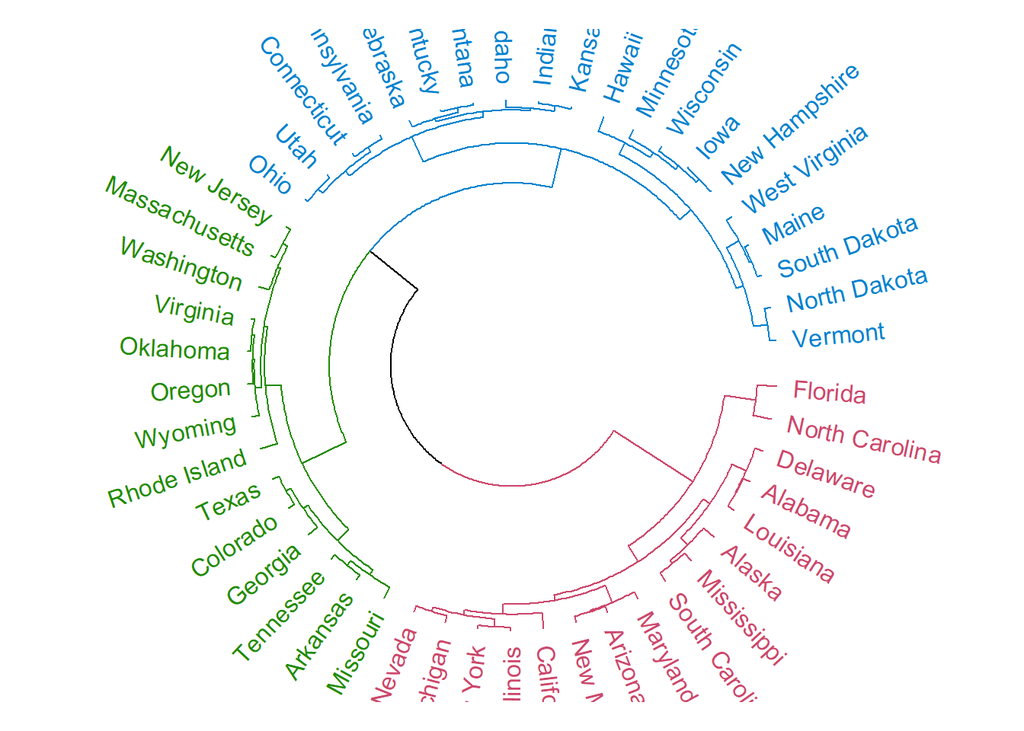

```r
hc <- hc %>%
  color_branches(k = 3) %>%
  color_labels(k = 3)

circlize_dendrogram(hc,
                    labels_track_height = 0.1,
                    dend_track_height = 0.5)
```

El tipo y grosor de las lineas se puede cambiar tal y como se muestra en el siguiente ejemplo.

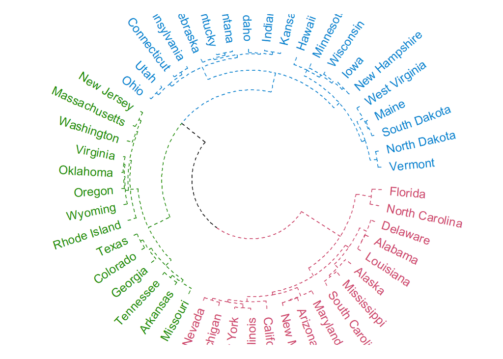

```r
hc <- hc %>%
  color_branches(k = 3) %>%
  set("branches_lwd", 1) %>%
  set("branches_lty", 2) %>%
  color_labels(k = 3)

circlize_dendrogram(hc,
                    labels_track_height = 0.1,
                    dend_track_height = 0.5)
```